# ESS Politics Regression

V. Markos

2026-11-24

# Loading and Cleaning

First we load our data to remember what they are about:

```r
ess_pol <- read.csv('ess_pol.csv', sep = ',')
head(ess_pol)
```

```
##   X ess_data.cntry ess_data.nwspol ess_data.netusoft ess_data.netustm
## 1 1             AT              90                 5              180
## 2 2             AT              90                 5              570
## 3 3             AT              30                 5               30
## 4 4             AT              15                 1             6666
## 5 5             AT              60                 5              120
## 6 6             AT             120                 5              120
##   ess_data.ppltrst
## 1                5
## 2               10
## 3                6
## 4                6
## 5                6
## 6                8
```

```r
str(ess_pol)
```

```
## 'data.frame':    50116 obs. of  6 variables:
##  $ X                : int  1 2 3 4 5 6 7 8 9 10 ...
##  $ ess_data.cntry   : chr  "AT" "AT" "AT" "AT" ...
##  $ ess_data.nwspol  : int  90 90 30 15 60 120 45 120 20 120 ...
##  $ ess_data.netusoft: int  5 5 5 1 5 5 1 5 5 1 ...
##  $ ess_data.netustm : int  180 570 30 6666 120 120 6666 240 180 6666 ...
##  $ ess_data.ppltrst : int  5 10 6 6 6 8 7 8 7 3 ...
```

Let us cleanup and save our data

```r
# Clean four/two-digit key-codes
for (v in c(77, 88, 99, 6666, 7777, 8888, 9999)) {
  ess_pol <- ess_pol[rowSums(ess_pol == v, na.rm = TRUE) == 0, ]
}
summary(ess_pol)
```

```
##        X           ess_data.cntry  ess_data.nwspol  ess_data.netusoft
##  Min.   :    1   Length   :38400   Min.   :   0.0   Min.   :4.000
##  1st Qu.:12003   N.unique :   30   1st Qu.:  30.0   1st Qu.:5.000
##  Median :24395   N.blank  :    0   Median :  60.0   Median :5.000
##  Mean   :24569   Min.nchar:    2   Mean   :  91.4   Mean   :4.901
##  3rd Qu.:37201   Max.nchar:    2   3rd Qu.:  90.0   3rd Qu.:5.000
##  Max.   :50116                     Max.   :1440.0   Max.   :5.000
##  ess_data.netustm ess_data.ppltrst
##  Min.   :   0.0   Min.   : 0.000
##  1st Qu.: 120.0   1st Qu.: 4.000
##  Median : 180.0   Median : 5.000
##  Mean   : 237.3   Mean   : 5.171
##  3rd Qu.: 300.0   3rd Qu.: 7.000
##  Max.   :1440.0   Max.   :10.000
```

Also, since countries form a categorical variables, we should treat it as a factor:

```r
ess_pol$ess_data.cntry <- as.factor(ess_pol$ess_data.cntry)
str(ess_pol)
```

```
## 'data.frame':    38400 obs. of  6 variables:
##  $ X                : int  1 2 3 5 6 8 9 11 12 13 ...
##  $ ess_data.cntry   : Factor w/ 30 levels "AT","BE","BG",..: 1 1 1 1 1 1 1 1 1 1 ...
##  $ ess_data.nwspol  : int  90 90 30 60 120 120 20 60 5 60 ...
##  $ ess_data.netusoft: int  5 5 5 5 5 5 5 5 5 5 ...
##  $ ess_data.netustm : int  180 570 30 120 120 240 180 120 60 120 ...
##  $ ess_data.ppltrst : int  5 10 6 6 8 8 7 5 5 6 ...
```

Since we are using this a lot, we should also save the cleansed values:

```r
write.csv(ess_pol, 'ess_pol_clean.csv', sep = ',')
```

# A First Theory

One idea, given the variables we have chosen is to look for any effects of the time people devote on politics news and the time they spend on the internet on a daily basis on their level of other people trust. Also, we should, most probably, take also countries into account or focus, first to a single country.

First, let us quickly look for potential correlations between ppltrst and the rest of our variables:

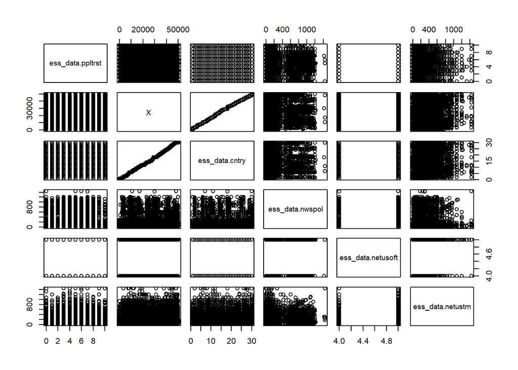

```r
pairs(ess_data.ppltrst ~ ., data = ess_pol)
```

Too much noise! So, first, we might want to study a particular country and then repeat maybe for all.

```r
ess_pol_den <- ess_pol[ess_pol$ess_data.cntry == 'DK', ]
str(ess_pol_den)
```

```
## 'data.frame':    0 obs. of  6 variables:
##  $ X                : int
##  $ ess_data.cntry   : Factor w/ 30 levels "AT","BE","BG",..:
##  $ ess_data.nwspol  : int
##  $ ess_data.netusoft: int
##  $ ess_data.netustm : int
##  $ ess_data.ppltrst : int
```

Okay, so, accidentally, we see that all Danish responses have been removed from our data. To test whether this is a general thing or just affects danish submissions we can create a barplot of our country counts:

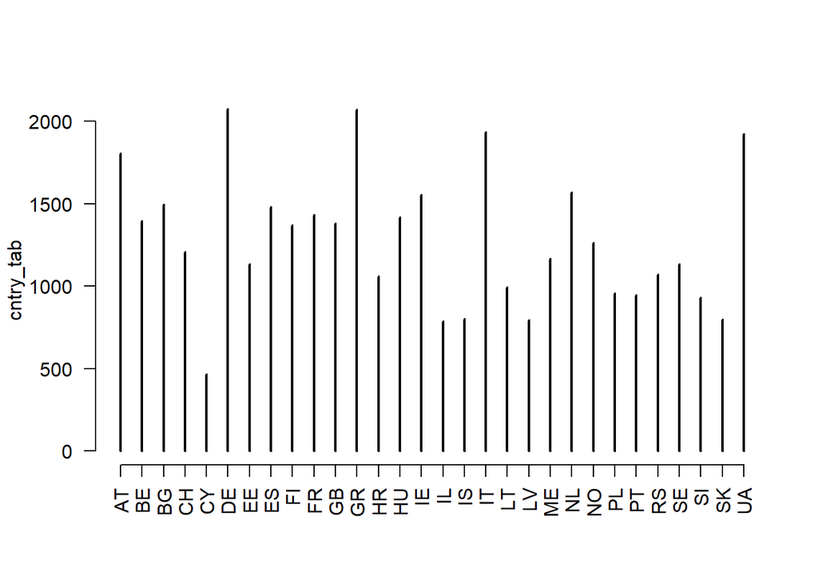

```r
cntry_tab <- table(ess_pol$ess_data.cntry)
plot(cntry_tab, las = 2)
```

It seems that danish participats were maybe too few and all of them have been excluded. To verify this, we just reload our data on a separate dataframe and plot the same barplot for them:

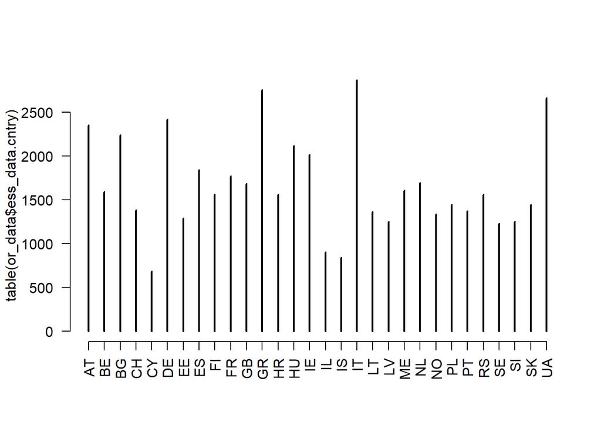

```r
or_data <- read.csv('ess_pol.csv', sep = ',')
or_data$ess_data.cntry <- as.factor(or_data$ess_data.cntry)
plot(table(or_data$ess_data.cntry), las=2)
```

So, thankfully enough, we have not eliminated danish participants, it is just that they were never there!

So, let us pick Italy, instead:

```r
ess_pol_it <- ess_pol[ess_pol$ess_data.cntry == 'IT', ]
summary(ess_pol_it)
```

```
##        X         ess_data.cntry ess_data.nwspol  ess_data.netusoft
##  Min.   :29035   IT     :1935   Min.   :   0.0   Min.   :4.000
##  1st Qu.:29746   AT     :   0   1st Qu.:  30.0   1st Qu.:5.000
##  Median :30489   BE     :   0   Median :  60.0   Median :5.000
##  Mean   :30470   BG     :   0   Mean   : 136.3   Mean   :4.831
##  3rd Qu.:31181   CH     :   0   3rd Qu.: 120.0   3rd Qu.:5.000
##  Max.   :31899   CY     :   0   Max.   :1420.0   Max.   :5.000
##                  (Other):   0
##  ess_data.netustm ess_data.ppltrst
##  Min.   :   0.0   Min.   : 0.000
##  1st Qu.: 100.0   1st Qu.: 3.000
##  Median : 150.0   Median : 5.000
##  Mean   : 186.8   Mean   : 4.716
##  3rd Qu.: 240.0   3rd Qu.: 6.000
##  Max.   :1440.0   Max.   :10.000
##
```

So, now, let us create those correlation plots on the above data:

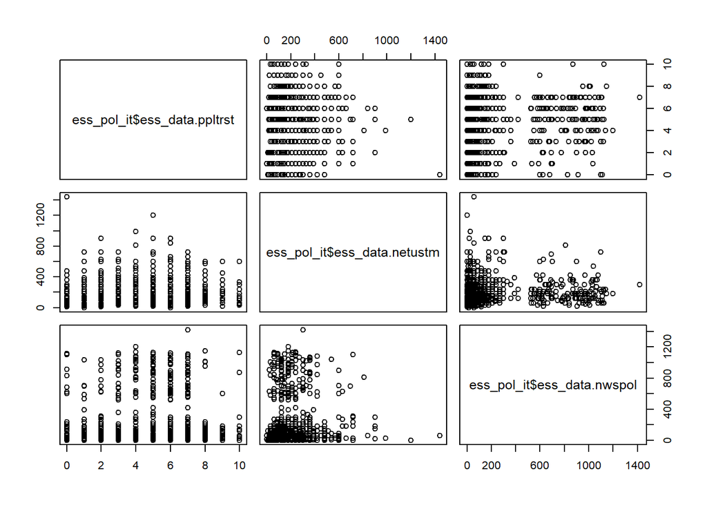

```r
pairs(ess_pol_it$ess_data.ppltrst ~ ess_pol_it$ess_data.netustm + ess_pol_it$ess_data.nwspol, data = ess_pol_it)
```

So, let us also compute the corresponding correlations:

```r
cor(ess_pol_it[, c('ess_data.ppltrst', 'ess_data.netustm', 'ess_data.nwspol')])
```

```
##                  ess_data.ppltrst ess_data.netustm ess_data.nwspol
## ess_data.ppltrst       1.00000000       0.04003617      0.03542418
## ess_data.netustm       0.04003617       1.00000000      0.07012535
## ess_data.nwspol        0.03542418       0.07012535      1.00000000
```

All correlations in this case, appear to bee too weak to be considered, so, we drop the idea of investigating further by using linear regression.

# What If…?

There are too many extreme values in the above, e.g., TV attendance of more than 1000 minutes per day, so we might also consider excluding extreme values:

```r
ess_pol_it <- ess_pol_it[ess_pol_it$ess_data.netustm <= 600, ]
ess_pol_it <- ess_pol_it[ess_pol_it$ess_data.nwspol <= 600, ]
```

Now, let us compute correlations again:

```r
cor(ess_pol_it[, c('ess_data.ppltrst', 'ess_data.netustm', 'ess_data.nwspol')])
```

```
##                  ess_data.ppltrst ess_data.netustm ess_data.nwspol
## ess_data.ppltrst       1.00000000       0.06929561      0.02577481
## ess_data.netustm       0.06929561       1.00000000      0.05404671
## ess_data.nwspol        0.02577481       0.05404671      1.00000000
```

Since correlations found are still too weak, we just drop this hypothesis.